# prepare

Aparna Nayak

11/9/2020

# Reading the file

```r
student <- read.csv("sperformance.csv")
```

#install packages

```r
needed_packages <- c("dplyr","ggplot2","VIM")
# Extract not installed packages
not_installed <- needed_packages[!(needed_packages %in% installed.packages()[ , "Package"])]
# Install not installed packages
if(length(not_installed)) install.packages(not_installed)
library("dplyr")
library("ggplot2")
library("VIM")
```

# Section 1

*Population and Sample*

Population describes the entire dataset on which the actual experiment should be carried on. Sample describes a subset of the entire population that is considered for the experiment. Samples must be randomly chosen, i.e. each data point of the larger population has an equal chance of being chosen. It must be large enough to as not to skew the results.

When we have to compute average height of all the people who live in Dublin, the population refers to every single individual living in Dublin where as sample refers to few people whose height is considered for the experiment.

EXAMPLE: Consider given student performance dataset. Population means the entire dataset i.e. the dataset contains 382 rows and 53 columns. Sample means a subset of the entire population. It may contain n rows where 0<n<382.

Parameter is one that describes the characteristics of the entire population whereas statistic describes the characteristics of the sample. Characteristics such as mean, number of observations, standard deviation, variance can be described for both population and sample. Ideally, behavior of statistic should be same as behavior of parameter. However, in real world, having exact same properties for both is non-viable.

Major difference between population and sample is number of observations it contains. Sample is a part of population which is smaller in size compared to the population. That means sample contains fewer observations compared to population. Sample should reflect all the properties that the population holds such as the type of distribution, mean, and all other characteristics. Researchers make use of sample rather than entire population and infer parameters for the population. This is possible because sample describes the entire population. However, selecting instances for sample that represents entire population is difficult. There exists multiple reasons to perform experiments on sample than on the entire population. Conducting experiment on the entire population sometimes maybe infeasible due to computation power, budget, time etc.

Considering the average height of all people who live in Dublin, if the height of every individual is considered for the experiment we can call it as parametric mean. If average height is computed for the sample data, we call it as statistical mean.

EXAMPLE: Consider final grade of student i.e. column pG3 in the dataset. Population mean i.e. μ is 12.52 is called parameter of the dataset. Sample mean x̄ of the same parameter is 12.15 for sample size 20 which is called as statistical mean.

Inferring population from a sample - Inferring population from a sample means describing the statistics of the entire population from the sample. A bell shaped curve is expected when the sample is drawn using histogram. A single peak symmetrical curve centered around the mean of the parameter is called normal distribution. The distribution of a normal variable with equal to zero and standard deviation to zero is called as standard normal distribution. However, in real life it is not possible to have standard normal distributed data. The standard normal distribution curve is converted to normal distribution with the help of z-score. A density curve describes the overall pattern of a distribution. A distribution is normal if its density curve is symmetric, single-peaked and bell-shaped. Mean, median and mode are same for a normal distribution.

Critical values are defined for a hypothesis test and depend upon a test statistic, specific to the type of test. These values are actually cut-off values of the interval within which the test statistic is unlikely to lie. These usually correspond to significance levels. The sensitivity of the test is defined by the significance level, denoted by alpha (α). The value of significance level implies the percentage where the null hypothesis gets rejected even after being true. The common values of significance levels in practice are 0.1, 0.05, and 0.01.

A confidence interval can be thought of as the inverse of significance level. It is equal to (1 - α) and written in percentage form i.e. 100(1 − α) %. It indicates that if samples are taken from the same population multiple times and intervals are estimated every time, then the percentage of times these intervals will include the actual parameter of the population will be equal to the confidence interval value. It usually comprises of a point estimate (most likely value) and a margin of error around it. This margin of error indicates the amount of uncertainty surrounding the sample estimate.

A confidence interval can be used to decide whether to reject a null hypothesis. This decision is based on the p-value and the chosen significance level α. If the p-value is less than or equal to α, one should reject the null hypothesis in favor of the alternative hypothesis. If the p-value turns out to be greater than α, then the null hypothesis is not rejected. Thus, it can be said that a smaller p-value strongly recommends to reject the null hypothesis.

There is another way to reject the null hypothesis using the critical value. It is by comparing the calculated value of the test statistic with the critical value. If the former is greater, then null hypothesis can be rejected.

Representativeness sample is a small portion or a subset of the entire population. It must accurately represent all the characteristics of the entire population. Representative sample is unbiased reflection of the entire population. Researcher can conduct experiment on the representative sample and infer the characteristics for the population. This is beneficial as it saves time, budget and computation power.

Considering the average height of the all people who live in Dublin, mean of representative sample is equal to mean of the population. All other characteristics(parameter) of the population is equal to the characteristics(statistic) of the representative sample.

# Sample and population

```r
cat("Total number of rows",nrow(student),fill=TRUE)
```

```
## Total number of rows 382
```

```r
cat("Total number of columns",ncol(student),fill=TRUE)
```

```
## Total number of columns 53
```

```r
cat("Dimension of the dataset",dim(student),fill=TRUE)
```

```
## Dimension of the dataset 382 53
```

# Section 2

**Describing sample**

A representative sample ensures that all relevant types of observations are included in the sample. Characteristics of the representative sample should reflect characteristics of the entire population. Thus, it helps to infer behavior of population without conducting the experiment on the entire population. Randomness allows each observation of the larger group to have equal chance of being chosen. It eliminates biasness when analysts have to infer parameters from statistics.

*Importance of having enough data in a sample:* Instances in the sample should reflect the characteristic of the entire population. Over and under sampled data may not the exhibit the characteristics of the entire population. Statistical model may perfectly fit the over sampled data, however, model may not work as required for other instances in the population. Over sampling means having more instances than required that means as good as considering additional instances from the population which is unnecessary. Under sampled data may discard some of the useful observations from the population. It also may not exhibit all the characteristics of the entire population.

There are two types of statistical measures. Descriptive statistics and Inferential statistics. Descriptive statistics used to describe the population and the sample. Inferential statistics used to infer from sample to population.

Numerical data can be described using centre(mean, median, mode), spread/dispersion(range, standard deviation, IQR), shape (symmetrical, uniform, skewed, bimodal). Unusual occurrences of numerical data can be identified using clusters, gaps and outliers. Categorical data can be described using frequency.

*Descriptive statistics:* Measure of central tendency : Mean, Median, Mode  
Measure of dispersion/variation: Range, Variance, Standard deviation  
Measure of frequency: Count, Frequency

*Inferential statistics:* Inferential statistics is used to infer conclusion about the population from the sample. The sample considered for the experiment must be representative and should reflect the population. Various tools that support inferential statistics are hypothesis testing, confidence interval and regression analysis.

*Missing data:*

Missing data means some of the observations from the entire population are not available. This reduces statistical power of the model. Missing data adds bias to the system and may complicate the analysis of the study.

There are three main reasons due to which observations in the population won’t be available.

1. Data missing at random(MAR): Missing data of a variable is related to other variables in the dataset. However, it is not related to observations that present in the dataset. For example, some of the countries had no facility to test the COVID in the initial days when COVID was detected. When the statistics taken across the countries, number of COVID cases are missing due to lack of COVID test facility and not due to zero COVID patients.
2. Data missing completely at random(MCAR): Observations that are missing in a variable is not related to any other variables in the dataset. Observations that are missing in not related to the observations that exist in the dataset. For example, in packet switching network, some of the data packets might get lost before reaching the destination during the transit due to network failure, bandwidth variation etc.
3. Data missing not at random(MNAR): Some of the observations are missed intentionally during data collection. For example, some people are not ready to share their age/salary during the survey. Such observations we can consider as data missing not at random.

MCAR has no effect on the final inference as the data is missing at random. MAR and MNAR may lead to wrong inferences if the missing data are ignored. In case of MAR and MNAR it is always better to model missing data before constructing model on it. Missing data is computed based on number of percentage of missing cases, percentage of variables having missing data and percentage of data values that are missing. It is the responsibility of the researcher to understand about the missing data before building the model considering that dataset. Multiple reasons that contribute to the missing data, some of them are lack of preventable errors, problems outside the control of the researcher, intentional or due to differential applicability of some items to subset of respondents. The following three strategy that yields the least biased methods.

1. Deletion methods: Deletion method consists of two techniques. Listwise deletion methods and pairwise deletion methods. In case of listwise deletion methods, all cases with missing values are deleted from the analysis. This method is beneficial only when the sample size is large enough. It introduces bias if the dataset does not satisfy MCAR. Pairwise deletion methods ignores the null values in the dataset and analysis is conducted on other variables. This method retains more information compared to listwise deletion as none of the cases are completely ignored from the analysis. MCAR assumption of the dataset does not lead to any unbiased estimates. However, inconsistency in sample size can lead to problems in computing standard errors.
2. Single imputation methods: Imputation method means replacing missing values with some other value. Missing value can be replaced with either mean or probable estimated value. Mean substitution is not accepted as it does not contribute any new information. However, it increases the sample size and leads to inconsistent bias due to inequality in the number of missing values. Regression imputation, helps to increase the sample size while without adding new information in the dataset.
3. Model-based methods: This method imputes the missing parameters that are calculated from the fuction. In case of maximum likelihood method, parameters are computed based on the available observations. The missing data are estimated based on the parameters that have been computed. This method helps to get unbiased estimates. However, this model is limited to linear models. Multiple imputation, imputes multiple values for each missing value and generates multiple complete dataset. This helps to average the results of the statistical analysis across these dataset.

Missing data can be treated depending on the sensitivity of the application in which the dataset is being used. Number of variables that have missing data, total percentage of missing data, sample size, reason for missing data(randomness) also needs to be considered when missing value has to be treated before analyzing. Deletion methods are inappropriate and imputation/ model-based methods are useful when the sample size is relatively small. Model based methods are useful as it is robust to the violation of the normality assumptions and produces appropriate results even in the presence of a sample size or a high number of missing data. Missing data pattern can be visualized using graphs to identify whether the observations are missing due to randomness.

# Section 3

**Hypothesis test**

Hypothesis testing helps to determine whether there is enough statistical evidence in favor of established fact about a parameter. Statisticians usually state two hypothesis(null, alternative) statements in which only one is correct. Statistical tests are carried out on sample data to statistically test the statements. Results of the experiments are analyzed either to accept the null hypothesis or reject the hypothesis for the given data.

Two hypothesis stated by analysts is usually mutually exclusive and only one statement among them is true at any given point. One of them is stated as null hypothesis and other one is alternative hypothesis. Usually, alternative hypothesis is opposite of a null hypothesis. Usually assumptions are equated in null hypothesis where as in alternative hypothesis it is less than, greater than or not equal to. Researchers usually disprove the null hypothesis, thus accepting the facts stated in alternative hypothesis. Statistical study becomes insignificant if the null hypothesis is accepted. We can conclude that result of the experiment is statistically significant if null hypothesis is rejected. Rejection of null hypothesis means we are accepting alternative hypothesis. Alternative hypothesis helps to establish new improved theories that are opposite to already known facts (null hypothesis).

#Section 4

# Getting a sample of size 20 from the entire population

In case if we have considered entire population sample observations can be selected randomly using sample_n function.

```r
dplyr::sample_n(student, size=20)
```

```
##    school sex age address famsize Pstatus Medu Fedu     Mjob     Fjob
## 1      GP   F  15       U     LE3       T    1    1  at_home    other
## 2      GP   F  18       U     GT3       T    2    3    other services
## 3      GP   F  17       R     LE3       T    3    1 services    other
## 4      GP   M  15       U     LE3       T    2    2 services   health
## 5      GP   F  17       U     LE3       T    2    2 services    other
## 6      GP   M  18       U     GT3       T    2    1 services services
## 7      GP   M  16       U     GT3       T    4    4 services services
## 8      GP   M  18       U     GT3       T    4    4  teacher services
## 9      GP   M  18       R     LE3       A    3    4    other    other
## 10     GP   M  16       R     GT3       T    4    3 services    other
## 11     MS   F  18       R     GT3       T    4    4    other  teacher
## 12     GP   M  17       R     GT3       T    2    2 services    other
## 13     GP   M  16       U     GT3       T    4    4 services services
## 14     GP   M  18       U     GT3       T    2    2    other    other
```

[output cut: 132 more lines]

# Section 5

**Discuss the size of the dataset**

```r
cat("Total number of rows",nrow(student),fill=TRUE)
```

```
## Total number of rows 382
```

```r
cat("Total number of columns",ncol(student),fill=TRUE)
```

```
## Total number of columns 53
```

```r
cat("Dimension of the dataset",dim(student),fill=TRUE)
```

```
## Dimension of the dataset 382 53
```

There are 382 rows and 53 columns in the dataset. This dataset indicates a sample from Portugese rather than entire population when compared to actual population of Portugal.

**Discuss the representativeness of the dataset**

Representativeness means sample of the dataset. Datapoints in the sample should be randomly selected so that all the observations have equal chance of getting selected. This reduces the bias of selecting the same observation getting selected in sample.

Dataset has the following distribution for the age of the students.

```r
cat("Range of student's age in the dataset",range(student$age),"\n")
```

```
## Range of student's age in the dataset 15 22
```

```r
cat("Summay of Age")
```

```
## Summay of Age
```

```r
summary(student$age)
```

```
##    Min. 1st Qu.  Median    Mean 3rd Qu.    Max.
##   15.00   16.00   17.00   16.59   17.00   22.00
```

Summary function allows us to get some insights about the data. It gives information about minimum, maximum, mean, median, 1st quantile and 3rd quantile.

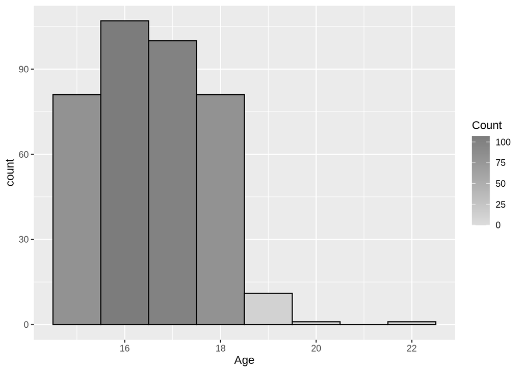

```r
gs <- ggplot(student, aes(x=age))
gs <- gs + labs(x="Age")
gs <- gs + geom_histogram(binwidth=1, colour="black", aes(y=..count.., fill=..count..))
gs <- gs + scale_fill_gradient("Count", low="#DCDCDC", high="#7C7C7C")
gs
```

Histogram represents distribution of the sample for the variable Age. We can see that the number of people having age 16 is more in the sample.

Age of students varies from 15 to 22. We can see that maximum students have age with range 15-18. Representativeness should reflect all the properties of the population. The given dataset has only 382 observations whereas the actual people with that age might be much more than this. As per unesco website (http://uis.unesco.org/country/PT) there are more than 1M people with age 15-24. Hence, the dataset considered has only 382 observations which is obviously a sample of the entire dataset.

**Identify your concepts of interest from the datasets**

Dataset has 53 variables. Four variables are considered that belongs to different kind of statistical data.

```r
varInterest <- c("famsup.p", "famrel.p", "traveltime.p","pG3")
```

**Description of variable of interest**

**Possible values of all variables that are of interest**

```r
#Family support(famsup.p)
factorFamilySupport <-factor(student[varInterest][1])
factorFamilySupport
```

```
## famsup.p
##     <NA>
## Levels: c("yes", "no")
```

```r
#Family relation(famsrel.p)
factorfamilyRelation <-factor(student[varInterest][2], order=TRUE, levels = c(1,2,3,4,5))
factorfamilyRelation
```

```
## famrel.p
##     <NA>
## Levels: 1 < 2 < 3 < 4 < 5
```

Sign “less than (<)” indicates the data is ordinal categorical.

```r
#traveltime(traveltime.p)
travelTime <-factor(student[varInterest][3], order=TRUE, levels = c(1,2,3,4))
travelTime
```

```
## traveltime.p
##         <NA>
## Levels: 1 < 2 < 3 < 4
```

```r
#Final grade (pG3)
range(student[varInterest][4])
```

```
## [1]  0 19
```

Range is used to know all possible values that final grade takes.

**Statistical measure type variables of interest**

```r
#Family support(famsup.p)
table(student[varInterest][1])
```

```
##
##  no yes
## 143 239
```

Since the data is categorical simple frequency method is better approach to describe the data.

```r
#Family relation(famsrel.p)
frequencyfamilyRelation <-table(student[varInterest][2])
temp = as.data.frame(frequencyfamilyRelation)
names(temp)[1] <- 'Frequency family relation'
temp
```

```
##   Frequency family relation Freq
## 1                         1    8
## 2                         2   18
## 3                         3   67
## 4                         4  184
## 5                         5  105
```

The above table shows number of students having different family relations.

```r
#traveltime(traveltime.p)
travelTime <-table(student[varInterest][3])
temp = as.data.frame(travelTime)
names(temp)[1] <- 'Frequency traveltime'
temp
```

```
##   Frequency traveltime Freq
## 1                    1  250
## 2                    2  102
## 3                    3   22
## 4                    4    8
```

The above table indicates number students who have different travel time to reach their school.

```r
#Final grade
cat("Median is ",median(student$pG3),"\n")
```

```
## Median is  13
```

```r
cat("IQR is ",IQR(student$pG3))
```

```
## IQR is  3
```

Final grade is interval type. So median and IQR is used to describe the data.

**Visuals**

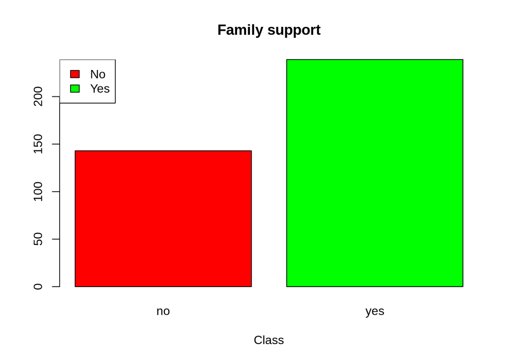

```r
#Family support(famsup.p) - BAR chart
barplot(table(student$famsup.p),
main = "Family support",
xlab = "Class",
col = c("red","green")
)
legend("topleft",
c("No","Yes"),
fill = c("red","green")
)
```

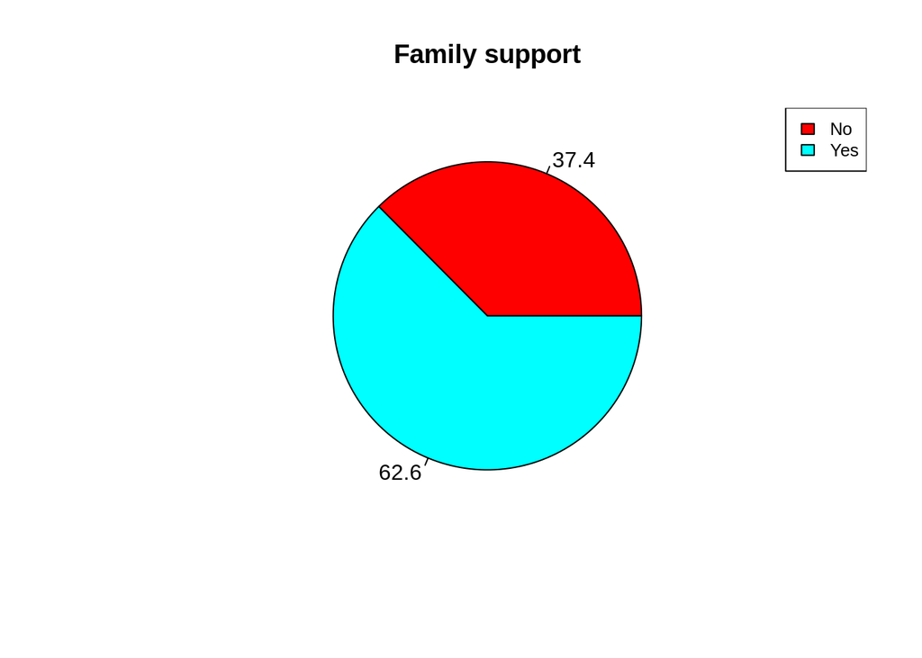

```r
#Family support(famsup.p) - pie chart

x <- table(student$famsup.p)
labels <-  c("No","Yes")

piepercent<- round(100*x/sum(x), 1)

pie(table(student$famsup.p), labels = piepercent, main = "Family support",col = rainbow(length(x)))
legend("topright", c("No","Yes"), cex = 0.8,
   fill = rainbow(length(x)))
```

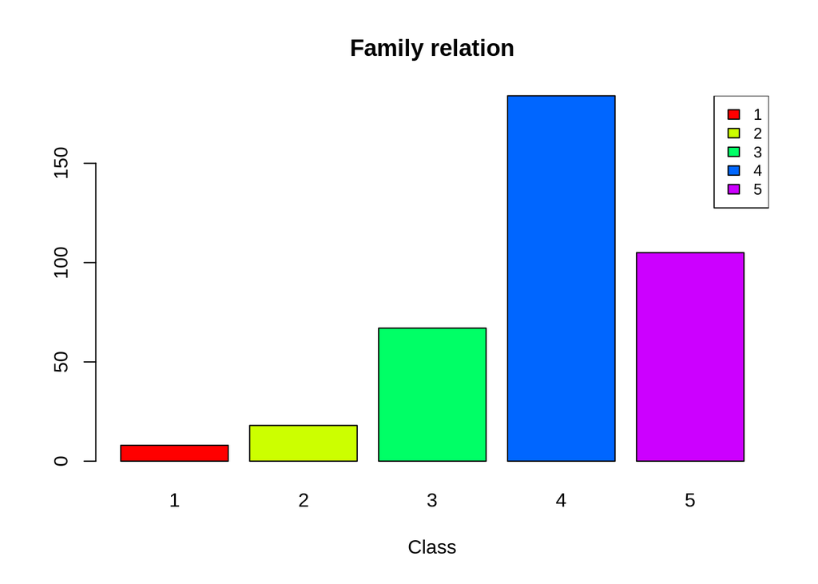

```r
#Family relation(famrel.p) - BAR chart

barplot(table(student$famrel.p),
main = "Family relation",
xlab = "Class",
col = rainbow(5)
)
legend("topright", c("1","2","3","4","5"), cex = 0.8, fill = rainbow(5))
```

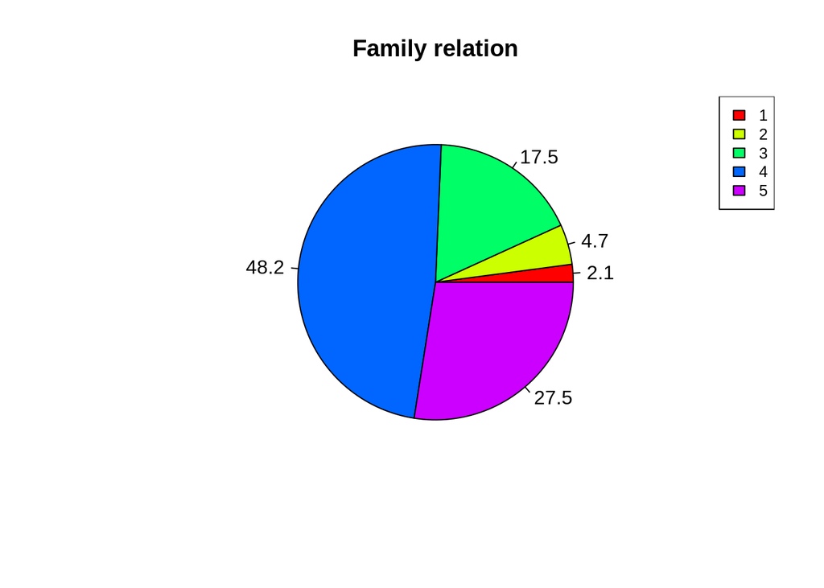

```r
x <- table(student$famrel.p)
labels <-  c(1,2,3,4,5)

piepercent<- round(100*x/sum(x), 1)

pie(table(student$famrel.p), labels = piepercent, main = "Family relation",col = rainbow(length(x)))
legend("topright", c("1","2","3","4","5"), cex = 0.8, fill = rainbow(length(x)))
```

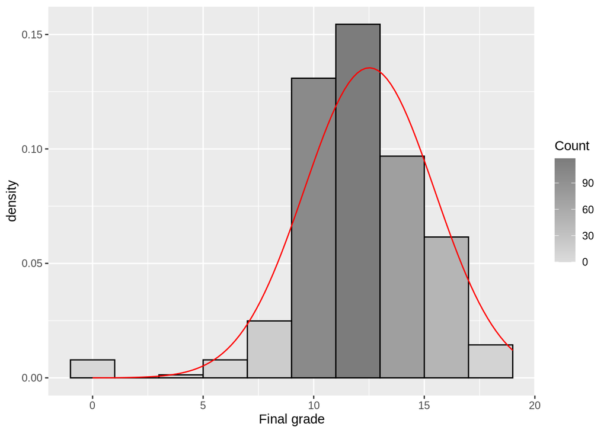

```r
#final grade
gs <- ggplot(student, aes(x=pG3))
gs <- gs + labs(x="Final grade")
gs <- gs + geom_histogram(binwidth=2, colour="black", aes(y=..density.., fill=..count..))
gs <- gs + scale_fill_gradient("Count", low="#DCDCDC", high="#7C7C7C")
gs <- gs + stat_function(fun=dnorm, color="red",args=list(mean=mean(student$pG3, na.rm=TRUE), sd=sd(student$pG3, na.rm=TRUE)))
gs
```

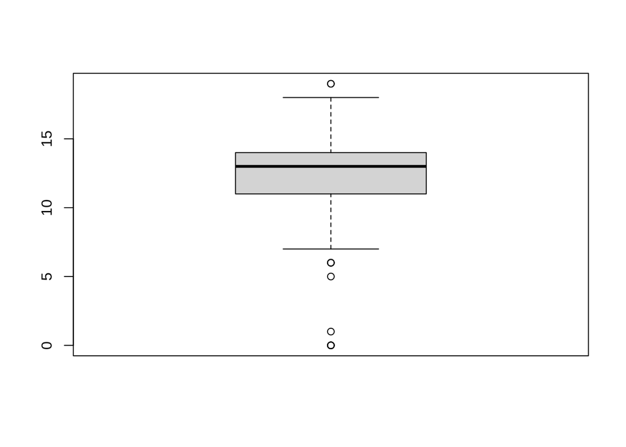

```r
boxplot(student$pG3)
```

**Assess for missing data and identify decisions you will make as a result**

```r
sum(is.na(student))
```

```
## [1] 0
```

There are no missing data in the sample. If missing data was present, as a analyst we have find reason for data missingness. If data is missing at completely random, final inferences won’t be effected.

```r
varsint <- c("age","address","pG2","pG3","famsup.p","famrel.p")
sdatasubset<-student[varsint]#create a subset of data with just the variables of interest
summary(sdatasubset)#Get our summary statistics - these are just for us not for publication
```

```
##       age          address               pG2             pG3
##  Min.   :15.00   Length:382         Min.   : 5.00   Min.   : 0.00
##  1st Qu.:16.00   Class :character   1st Qu.:11.00   1st Qu.:11.00
##  Median :17.00   Mode  :character   Median :12.00   Median :13.00
##  Mean   :16.59                      Mean   :12.24   Mean   :12.52
##  3rd Qu.:17.00                      3rd Qu.:14.00   3rd Qu.:14.00
##  Max.   :22.00                      Max.   :19.00   Max.   :19.00
##    famsup.p            famrel.p
##  Length:382         Min.   :1.000
##  Class :character   1st Qu.:4.000
##  Mode  :character   Median :4.000
##                     Mean   :3.942
##                     3rd Qu.:5.000
##                     Max.   :5.000
```

For demonstration purpose 6 variables are considered as variable of interest.

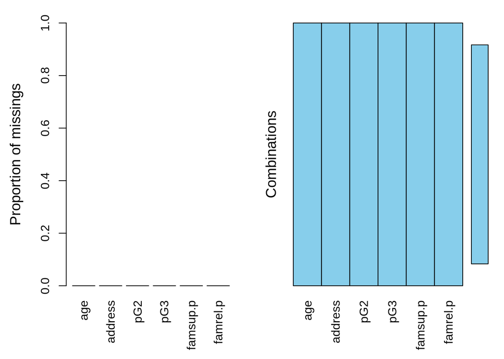

```
##
##  Variables sorted by number of missings:
##  Variable Count
##       age     0
##   address     0
##       pG2     0
##       pG3     0
##  famsup.p     0
##  famrel.p     0
```

```r
#pattern of missingness
res<-summary(VIM::aggr(sdatasubset, sortVar=TRUE))$combinations
```

Since the data has no missing values we don’t see any patterns in the graph. Otherwise left most graph gives the proportion of the variable wise missing value in the entire sample. Rightmost graph is uniform due to the fact that there are no missing data. Missing observations would have been highlighted and pattern can be seen to understand whether the data missing is by random or not.

**Hypothesis**

H0 : The quality of family relationship has no effect on the final grade of the student.

H1 : The quality of family relationship has effect on the final grade of the student.

| Variable name | famrel.p, pG3 |
| --- | --- |
| Variable type | famrel.p - ordinal , pG3 - interval |
| Independent variable | famrel.p |
| Dependent variable | pG3 |

H0 : There is no difference in final grade for students who have family support and those who do not have family support.

| Variable name | famsup.p, pG3 |
| --- | --- |
| Variable type | famsup.p - nominal ; pG3 - interval |
| Independent variable | famsup.p |
| Dependent variable | pG3 |

H0 : There is no relationship between travel time to reach school and final grade.

H1 : There is a relationship between travel time to reach school and final grade.

| Variable name | traveltime, pG3 |
| --- | --- |
| Variable type | traveltime - ordinal ; pG3 - interval |
| Independent variable | traveltime |
| Dependent variable | pG3 |

# References

1. Factor in R: Categorical Variable & Continuous Variables - https://www.guru99.com/r-factor-categorical-continuous.html
2. How to Get the Frequency Table of a Categorical Variable as a Data Frame in R - https://chemicalstatistician.wordpress.com/2015/02/03/how-to-get-the-frequency-table-of-a-categorical-variable-as-a-data-frame-in-r/

# Additional tests conducted

```r
cat("Range of student's grade(2) in the dataset (",range(student$pG2),") \n\n")
```

```
## Range of student's grade(2) in the dataset ( 5 19 )
```

```r
summary(student$pG2)
```

```
##    Min. 1st Qu.  Median    Mean 3rd Qu.    Max.
##    5.00   11.00   12.00   12.24   14.00   19.00
```

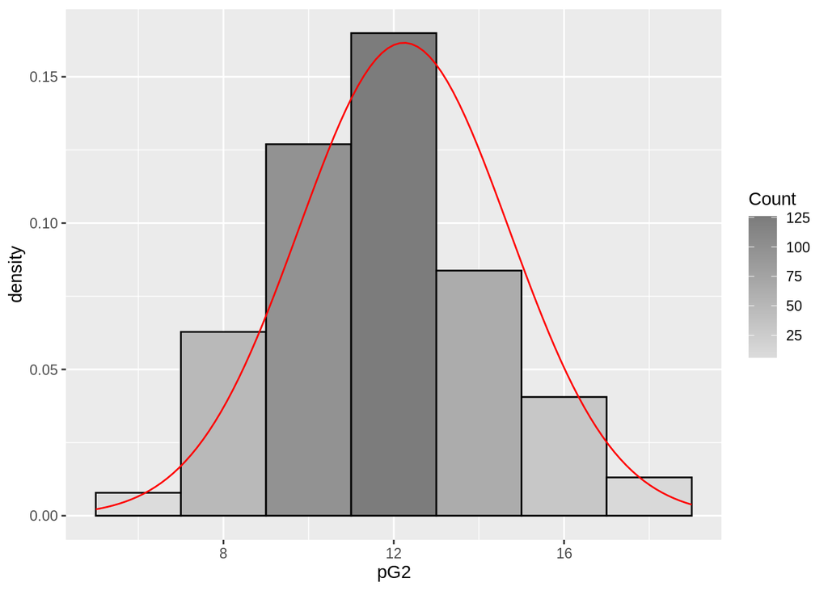

```r
gs <- ggplot(student, aes(x=pG2))
gs <- gs + labs(x="pG2")
gs <- gs + geom_histogram(binwidth=2, colour="black", aes(y=..density.., fill=..count..))
gs <- gs + scale_fill_gradient("Count", low="#DCDCDC", high="#7C7C7C")
gs <- gs + stat_function(fun=dnorm, color="red",args=list(mean=mean(student$pG2, na.rm=TRUE), sd=sd(student$pG2, na.rm=TRUE)))
gs
```

We can see that pG2 has near to normal distribution.

```r
cat("Range of student's grade(3) in the dataset",range(student$pG3),"\n")
```

```
## Range of student's grade(3) in the dataset 0 19
```

```r
summary(student$pG3)
```

```
##    Min. 1st Qu.  Median    Mean 3rd Qu.    Max.
##    0.00   11.00   13.00   12.52   14.00   19.00
```

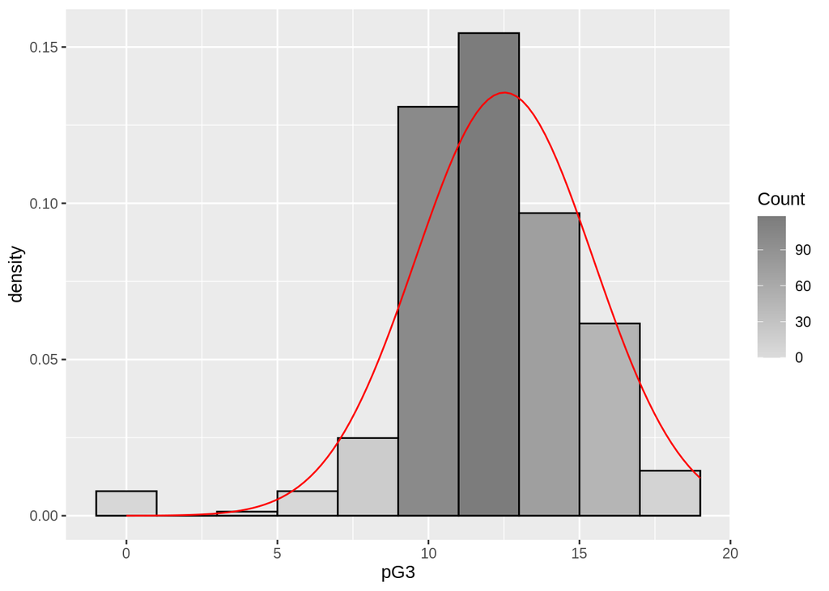

```r
gs <- ggplot(student, aes(x=pG3))
gs <- gs + labs(x="pG3")
gs <- gs + geom_histogram(binwidth=2, colour="black", aes(y=..density.., fill=..count..))
gs <- gs + scale_fill_gradient("Count", low="#DCDCDC", high="#7C7C7C")
gs <- gs + stat_function(fun=dnorm, color="red",args=list(mean=mean(student$pG3, na.rm=TRUE), sd=sd(student$pG3, na.rm=TRUE)))
gs
```

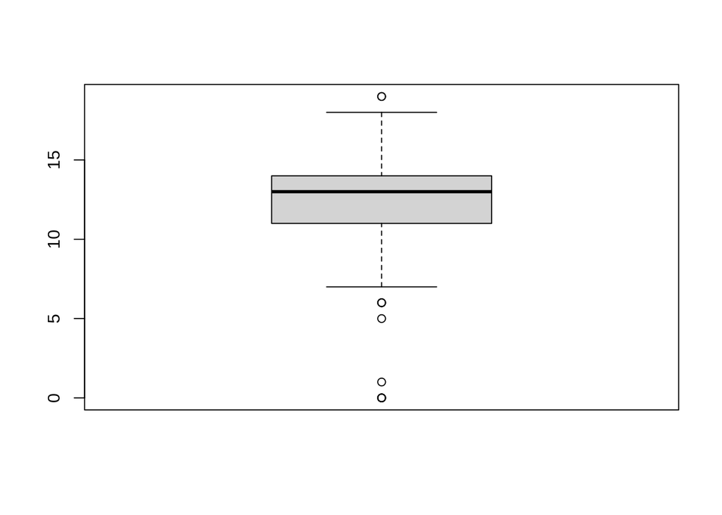

```r
boxplot(student$pG3)
```

Boxplot helps to visualize outliers, skewness, and kurtosis. Dots on both sides represents the outliers.

```r
summary(student$absences.p)
```

```
##    Min. 1st Qu.  Median    Mean 3rd Qu.    Max.
##   0.000   0.000   2.000   3.673   6.000  32.000
```

Range of absence varies from 0-32. There are many students who were absent only for 0-5 classes.

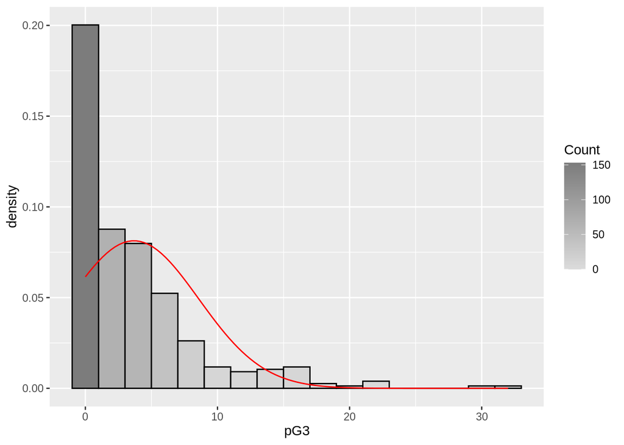

```r
gs <- ggplot(student, aes(x=absences.p))
gs <- gs + labs(x="pG3")
gs <- gs + geom_histogram(binwidth=2, colour="black", aes(y=..density.., fill=..count..))
gs <- gs + scale_fill_gradient("Count", low="#DCDCDC", high="#7C7C7C")
gs <- gs + stat_function(fun=dnorm, color="red",args=list(mean=mean(student$absences.p, na.rm=TRUE), sd=sd(student$absences.p, na.rm=TRUE)))
gs
```

```r
#Summary of age: Age is numeric continuous variable.
cat("Summery age: \n")
```

```
## Summery age:
```

```r
summary(student$age)
```

```
##    Min. 1st Qu.  Median    Mean 3rd Qu.    Max.
##   15.00   16.00   17.00   16.59   17.00   22.00
```

```r
#A
cat("Summary family relationship: \n")
```

```
## Summary family relationship:
```

```r
summary(student$famrel.p)
```

```
##    Min. 1st Qu.  Median    Mean 3rd Qu.    Max.
##   1.000   4.000   4.000   3.942   5.000   5.000
```

```r
cat("\n\n")
```

```r
cat("Summary of family relationship: \n")
```

```
## Summary of family relationship:
```

```r
tFamsupport <- table(student$famsup.p)
cat("Number of students who have family support: \n")
```

```
## Number of students who have family support:
```

```r
print(tFamsupport)
```

```
##
##  no yes
## 143 239
```

```r
cat("Percentage of students who have family support: \n")
```

```
## Percentage of students who have family support:
```

```r
prop.table(tFamsupport)
```

```
##
##        no       yes
## 0.3743455 0.6256545
```

```r
cat("\n\n")
```

```r
cat("Summary of student's address: \n")
```

```
## Summary of student's address:
```

```r
tAddress <- table(student$address)
cat("Number of students who have live in rural and urban areas: \n")
```

```
## Number of students who have live in rural and urban areas:
```

```r
print(tAddress)
```

```
##
##   R   U
##  81 301
```

```r
cat("Percentage of students who have live in rural and urban areas: \n")
```

```
## Percentage of students who have live in rural and urban areas:
```

```r
prop.table(tAddress)
```

```
##
##         R         U
## 0.2120419 0.7879581
```

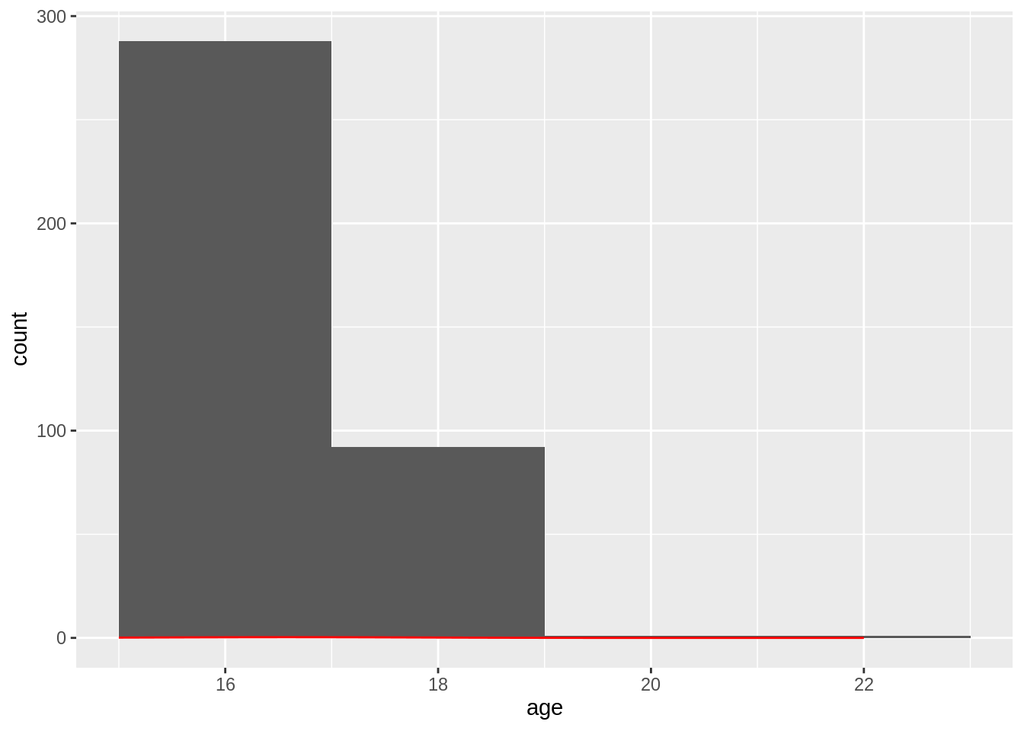

```r
gs <- ggplot(student, aes(x=age))
gs <- gs + labs(x="age")
gs <- gs + geom_histogram(binwidth=2)
gs <- gs + scale_fill_gradient("Count", low="#DCDCDC", high="#7C7C7C")
gs <- gs + stat_function(fun=dnorm, color="red",args=list(mean=mean(student$age, na.rm=TRUE), sd=sd(student$age, na.rm=TRUE)))
gs
```

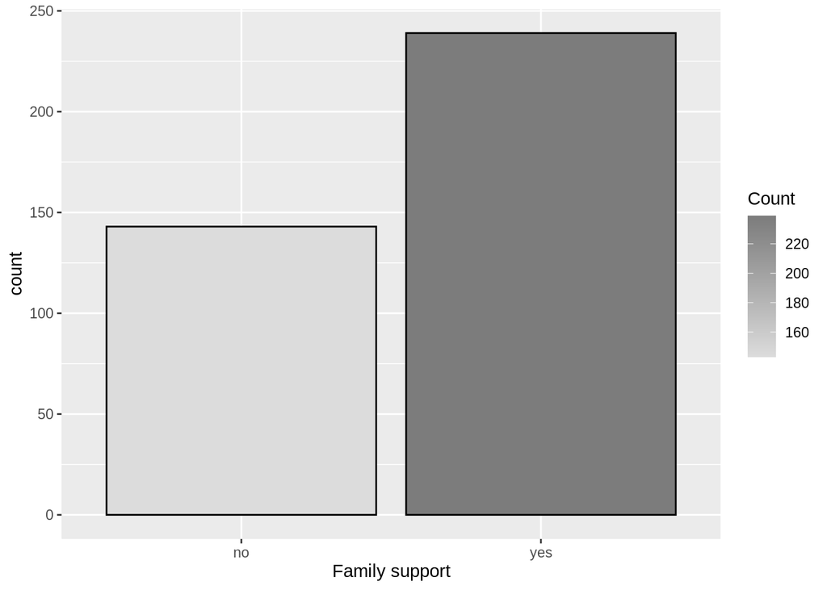

```r
gs <- ggplot(student, aes(x=famsup.p))
gs <- gs + labs(x="Family support")
gs <- gs + stat_count(binwidth=0.5, colour="black", aes(y=..count.., fill=..count..))
gs <- gs + scale_fill_gradient("Count", low="#DCDCDC", high="#7C7C7C")
gs
```

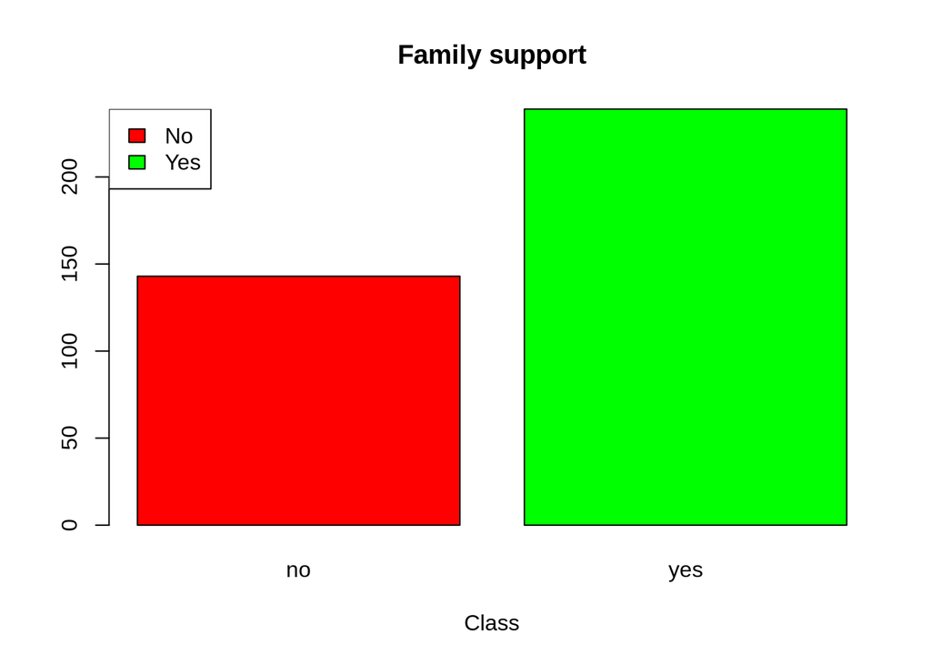

```r
barplot(table(student$famsup.p),
main = "Family support",
xlab = "Class",
col = c("red","green")
)
legend("topleft",
c("No","Yes"),
fill = c("red","green")
)
```

```r
x <- table(student$famsup.p)
labels <-  c("No","Yes")

piepercent<- round(100*x/sum(x), 1)
cat("Percentage of students who have support from family: \n")
```

```
## Percentage of students who have support from family:
```

```r
print(piepercent)
```

```
##
##   no  yes
## 37.4 62.6
```

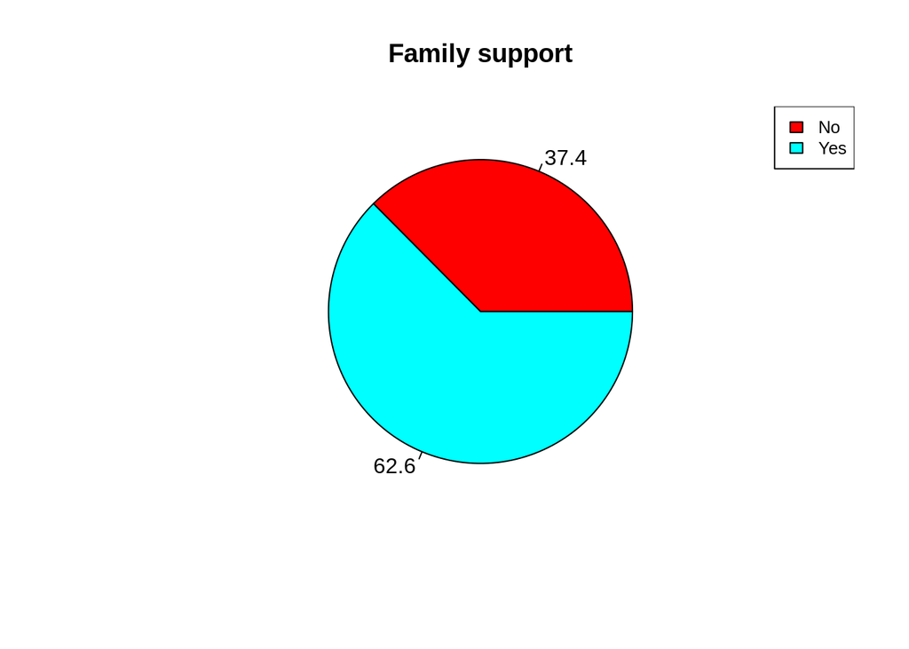

```r
pie(table(student$famsup.p), labels = piepercent, main = "Family support",col = rainbow(length(x)))
legend("topright", c("No","Yes"), cex = 0.8,
   fill = rainbow(length(x)))
```

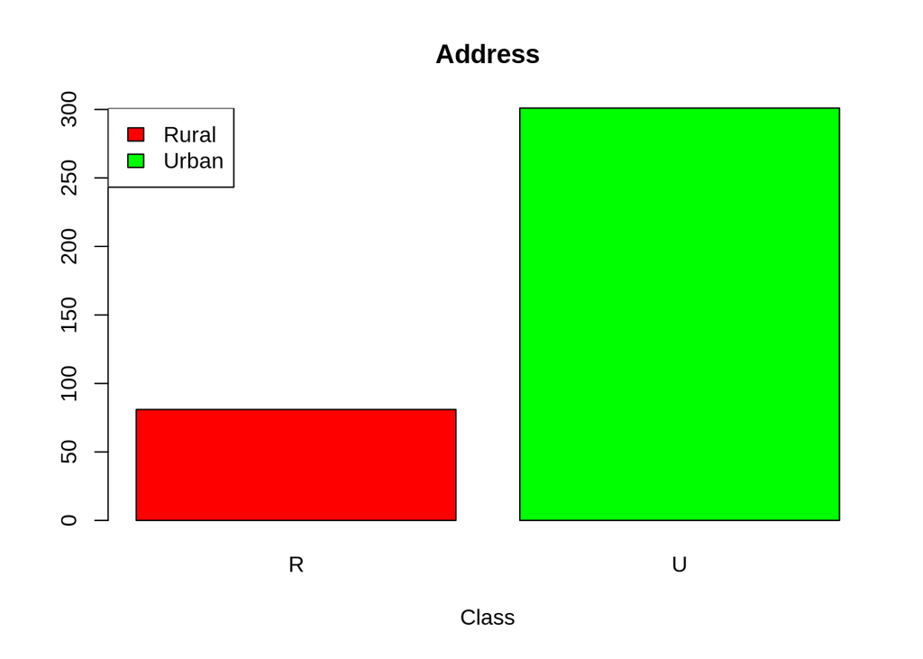

```r
barplot(table(student$address),
main = "Address",
xlab = "Class",
col = c("red","green")
)
legend("topleft",
c("Rural","Urban"),
fill = c("red","green")
)
```

```r
x <- table(student$address)
labels <-  c("Rural","Urban")

piepercent<- round(100*x/sum(x), 1)

cat("Percentage of students who live in rural and urban area: \n")
```

```
## Percentage of students who live in rural and urban area:
```

```r
print(piepercent)
```

```
##
##    R    U
## 21.2 78.8
```

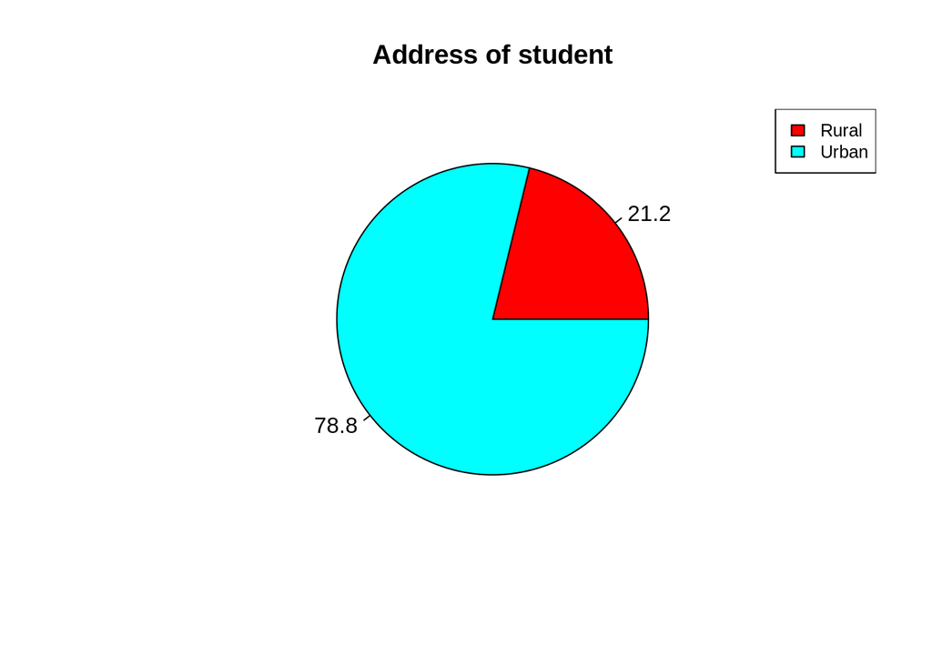

```r
pie(table(student$address), labels = piepercent, main = "Address of student",col = rainbow(length(x)))
legend("topright", c("Rural","Urban"), cex = 0.8,
   fill = rainbow(length(x)))
```